# My Probability of Hitting the Bullseye

Chad Worley

2024 Sep 27

# Research Question

I like to practice archery. At least 3 times per week I set up at my backyard target and shoot a few dozen arrows. While I was shooting, I realized I could gather data to address the question, “What is my probability of hitting the bullseye?”

# Data

In this case, the population is all the arrows I could possibly shoot while at this skill level. Because I’ve been shooting consistently for years, I do not expect my skill level is changing rapidly. During a round of shooting, I might start off with a lower probability than midway through, and then I might get worse after getting tired. I don’t have data to back that up, but it seems like a possibility. Also, some days I might be better than other days.

In short, we can see the idea that I could take a simple random sample is impossible. However, because this is simply a high-school report that is more focused on the analysis, I decided to just use data from a single round of shooting 36 arrows. Maybe this round of 36 arrows is not truly representative of the larger population of the million arrows I could shoot, but for the sake of this project, it seemed good enough.

Each arrow either hit a bullseye or missed the bullseye. A hit was marked with a 1, and a miss was marked with a 0. The raw data are shown below.

0, 0, 0, 0, 1, 0, 0, 0, 0, 0, 0, 0, 0, 1, 0, 1, 0, 0, 0, 0, 0, 0, 0, 0, 0, 1, 0, 1, 1, 0, 0, 0, 0, 0, 0, 1

By adding up the data, I found that I hit 7 bullseyes and missed 29 times.

# Analysis

I calculated a confidence interval two different ways: formulaic and bootstrapping.

## Formulaic

First, we can determine the sample proportion.

$$\widehat{p}=\frac{7}{36} =
0.1944$$

Because I am investigating a proportion, I used the following formula to get a formulaic margin of error:
$$\mathrm{ME} = 2\cdot \frac{\sqrt{0.1944\cdot
(1-0.1944)}}{\sqrt{36}}\approx 0.132$$

To get my formulaic confidence interval, I subtract or add the margin of error to the sample proportion to get the boundaries.

$$0.1944-0.132=0.062$$
$$0.1944+0.132=0.326$$
Formulaic confidence interval: [0.062,0.326].

## Bootstrapping

To run a bootstrap analysis to get a confidence interval, we assume that by resampling from the [empirical distribution](https://en.wikipedia.org/wiki/Empirical_distribution_function), we can get a good estimate of the margin of error. In this case, our empirical distribution is a [Bernoulli distribution](https://en.wikipedia.org/wiki/Bernoulli_distribution) with a probability of 0.1944.

- My empirical distribution:

| Possibility | Probability |
| --- | --- |
| 0 | 0.8056 |
| 1 | 0.1944 |

Which is equivalent to getting data by spinning the spinner below (generated based on the 36 datapoints collected).

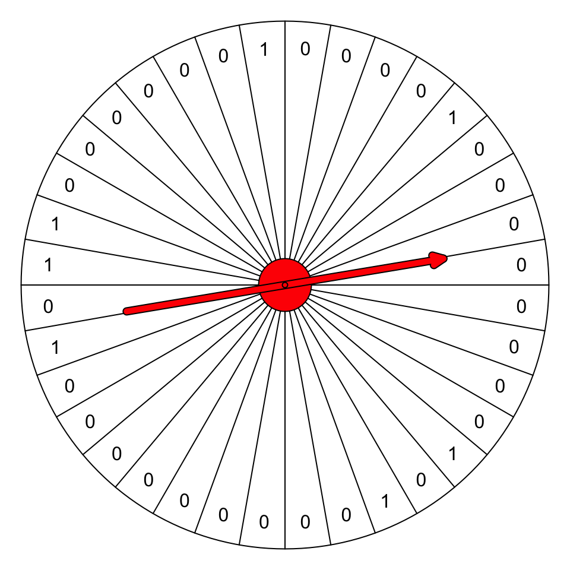

Using a spreadsheet, I simulated 1000 repetitions of spinning the above spinner 36 times (with `=IF(RAND()<7/36,1,0)` for each spin). Each repetition generated a proportion. I’ve graphed those proportions below with a histogram.

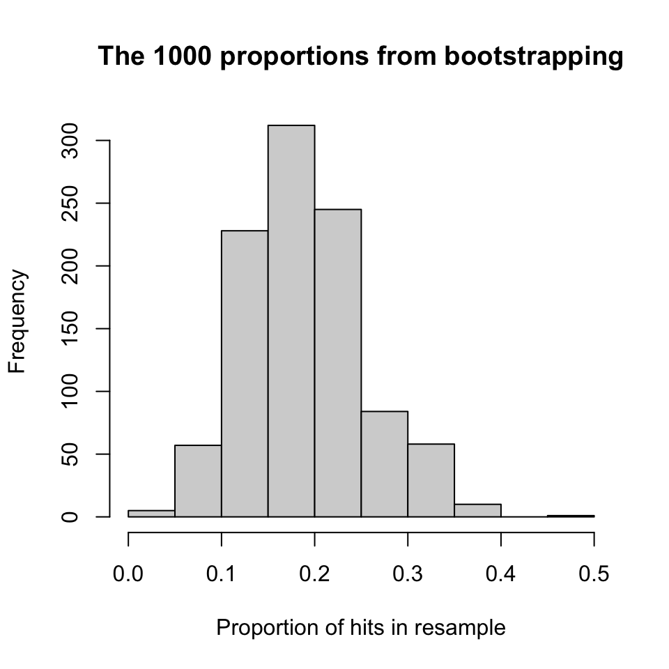

By finding the 2.5th percentile and the 97.5th percentile of these proportions, we get the confidence interval from bootstrapping.
$$\text{2.5th percentile}=0.083$$
$$\text{97.5th percentile}=0.333$$

Thus my bootstrap confidence interval is $[0.083,0.333]$. I can get the margin of error by halfing the difference of those boundaries.
$$\text{bootstrap ME} = \frac{0.333-0.083}{2} =
0.12$$

# Conclusion

Both confidence intervals basically agree. Because the bootstrap method is more robust, I will continue with those specific numbers. My conclusion is pretty simple. I can say that I am 95% confident that my probability of hitting a bullseye is between 0.083 and 0.333.

I’ll point out that this is a rather large confidence interval. In the future I would be interested in collecting more data to narrow in on the true probability. I’d also like to collect data from multiple days to average out the day-to-day variability.